# POLI 572B

Michael Weaver

January 9, 2026

# Potential Outcomes and Causal Inference

# Introduction

## What are we doing in this course?

One set of a tools to help us scientifically interrogate claims about causal relationships.

## Why causality?

- all of our questions/arguments ultimately connect to some set of causal claims
- appears to be *a priori* category of our understanding
- “innate” disposition to attribute causal relations

## Why science?

We can easily concoct causal explanations for phenomena/experiences that are **wrong**

- Need guiding principles to reign our thinking in.

## Severity

#### (weak) severity principle:

> *One does not have evidence for a claim if nothing has been done to rule out the ways the claim may be false.* If data x agree with a claim C, but the method is … guaranteed to find such agreement, and had little or no capability of finding flaws with C even if they exist, they we have bad evidence, no test

(Mayo 2018, pp. 5)

## Weak Severity

This principle can guide us at all stages of research:

- When we propose theory to explain some phenomenon: have we considered rival explanations?
- When linking theory/claim to observable hypothesis: do other explanations make same predictions? (Could our theory “pass” the test but nevertheless be wrong?)
- When we collect data: do our procedures for observing the world bias us toward “passing” the test?
- When we analyze data: do our procedures for comparison/interpretation bias us toward “passing” the test?

## Severity

(strong) severity requirement:

> *We have evidence for a claim C just to the extent it survives stringent scrutiny.* If C passes a test that was highly capable of finding flaws or discrepancies from C, and yet none or few are found, then the passing result, $x$, is evidence for C.

(Mayo 2018, pp. 14)

We want to deliberately engage with ways in which our claim and evidence for that claim may be wrong.

## Strong Severity

Severity principle does not REQUIRE statistics (or even quantitative data).

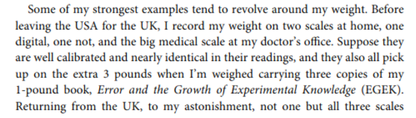

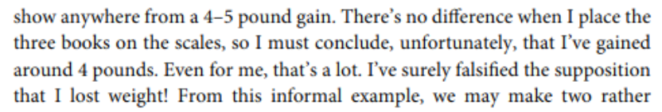

What about this procedure makes it “highly capable” of finding the claim that “Mayo gained weight” to be wrong?

## Severity, Statistics, Causality

Statistical methods not needed, but they are a (potentially) potent tool to help us achieve tests with strong severity

- help us clarify the ways in which evidence of causality may be wrong
- identify (and sometimes check) assumptions required to infer causality
- assign probability to whether test procedure will let our causal claim “pass” its test **in error**

## Severity and Falsification:

Severity as a criterion of evidence relates to falsification: we are not interested in inferring that claim is true from tests; we are interested in testing whether claim is false

$H$: All swans are white.

$H \to O$: See no swans of other colors

$not \ O \to not \ H$: Black swan $\to$ claim is false

## Severity and Falsification:

Falsification not actually so simple (Duhem, in Mayo 2018, pp. 84-6)

Any statistical test of a claim involves, in addition to the hypothesis $H$:

- assumptions about links between the theory/claim and observable phenomena ($A_1 \dots A_k$)
- assumptions of the statistical model ($E_1 \dots E_k$)

If the claim “fails” a test, it could be that $H$ is wrong. Or any $A_1 \dots A_k$, $E_1 \dots E_k$.

> “The only thing the experiment teaches us is … there is at least one error; but where this error lies is just what it does not tell us.”

Strong severity involves doing the work to **rule out** the possibility that it is an incorrect assumption made in the test that leads us to say evidence supports/rejects our claim.

## Course Goals

Understand canonical statistical designs and models used for testing causal hypotheses, such that:

- you can interpret their results
- know and understand the assumptions they entail
- for each assumption, know how to :
  - test/check its correctness using data
  - if not testable, give justifications
  - show whether results of tests change when changing/relaxing them
- We will see that contextual (“qualitative”) knowledge is required for this

## Course Goals

Meta-level:

- Be a competent/honest severe tester (in your work; as a reviewer of others)
- you know how to learn about new models/designs and their assumptions as well

## Course Agenda

Tests of causal theories/claims/hypotheses involve making additional assumptions…

- about match between theory and empirical test (quantitative or otherwise)
- about the link between observed data and the proposed test of the theory
- **when choosing a research design**
- **when choosing a particular statistical model for testing**

## Course Agenda

When using/evaluating statistical tools… ask:

- **What is causal estimand that our research design gives us?** Is it relevant to our theory/hypothesis?
- **What are the assumptions of the (canonical) estimator for this design?**
  - to get **unbiasedness** in causal estimates
  - to get correct **error probabilities**
- **How might these *design* assumptions be violated?** Can we test/relax/defend this assumption?
- **How does statistical *model* we estimate match our estimand?**
- **What additional assumptions does statistical model impose?**: (for unbiasedness? for error probabilities?)
- **What are the ways these *model* assumptions can be violated?** Can we test/relax/defend this assumption?

## Syllabus

- Group Project
- Problem Sets

## Syllabus

- Read before class; don’t suffer too long on equations. Revisit equations after class.
- Shifting toward Aronow and Miller textbook; Mostly Harmless Econometrics is good, but a bit dated (on differences in differences, standard errors)
- Supplemental readings can be remedial (you’re feeling lost); advanced (need more gory detail)

# Testing Causal Claims

## Do Social Media Algorithms Drive Political Polarization?

Everyone says yes, but how do we know?

## Social Media Drives Polarization?

Piccardi et al

- summarize the experiment
- how does this relate to social media and polarization?

## Social Media Drives Polarization?

#### In pairs:

What do the authors do to subject claim that social media algorithms drive polarization to severe testing? (What specific role do **statistical** tests play in assessing whether social media algorithms **cause** polarization?)

## Compare and contrast

> Piccardi et al use simple $t$ tests (in a regression context) to compare differences in means

> “The power of multiple regression analysis is that it allows us to do in non-experimental environments what natural scientists are able to do in a controlled laboratory setting: keep other factors fixed” (Wooldridge 2009: 77)

## Design vs. Model-based inferences

A matter of **degree**

Statistical evidence for causality combines **observed data** and a **mathematical model** of the world.

- mathematical model makes inferences about reality
- model always involves assumptions about how observed data are generated
- can almost always apply the model, even if it is wrong

## Design vs. Model-based inferences

Causal evidence varies in terms of complexity of math/restrictiveness of assumptions: a matter of **degree**

- **Model-based** inferences about causality involve many choices in complex statistical models with many difficult-to-assess assumptions
- **Design-based** inferences about causality use carefully controlled comparisons with simple models and transparent assumptions

## Objectives

- Counterfactual Causality
- Potential Outcomes
- Causal Effects (unit, average, etc.)
- Partial Identification
- Neyman Causal Model (Point Identification)

# Causality

## What is causality?

**What does it mean to say that social media feed algorithms *cause* political polarization?**

## What is causality?

Causality is…

### (1) Counterfactual

- A statement of what the state of the world would have been had prior events been different

> “If legal cannabis policy had not been adopted, then Y…”
- For some putative cause $C$, **causal effect** of $C$ is the difference between the two, otherwise identical, states of the world where $C$ is present versus absent.

## What is causality?

Causality is…

### (2) Manipulation

Causality requires something acting on another (a mechanism)

- e.g. barometer and storms

## What is causality?

### Counterfactual and manipulation together:

- counterfactuals without manipulation do not give us the direction of causality
- manipulation without counterfactuals may yield spurious conclusions

## Potential Outcomes

A powerful way to formalize a mathematical model of causality

## Potential Outcomes

Imagine you were a participant in an experiment similar to the Piccardi et al paper…

Imagine that, today, you were asked whether you’d have lunch with a supporter of a rival political party (0 being no, 1 being yes).

Write down: what would be your feeling (0 being no, 1 being yes)…

- … if, yesterday, you were in the **no change** group
- … if, yesterday, you were in the **downranking** group

## Potential Outcomes

In an experiment with two conditions: each subject, prior to intervention has two possible states that it could take.

If $Y_i$ is the willingness to have lunch with person $i$; $Z_i$ is the experimental condition: $1$ indicates downranking, $0$ no change, then we have two **potential outcomes**

1. lunch status with **no change** is $Y_i(0)$
2. lunch status **with downranking** is $Y_i(1)$

More generally: $Y_i(Z_i \in (0,1))$

## Potential Outcomes

**on the board**, let’s make a table of potential outcomes corresponding to this thought experiment

## Potential Outcomes

Tables of potential outcomes for different units are **response schedules**

- a general tool for thinking of how units behave under different possible counterfactual conditions

## Potential Outcomes

Potential outcomes help us mathematically describe causal effects.

The **unit causal effect** of contact for person $i$ is the **difference** between the potential outcomes:

$$\tau_i = Y_i(1) - Y_i(0)$$

*n.b.* $\tau$ and other Greek letters used to stand in for quantities of interest. Here, presumably for “**t**reatment effect”.

## Potential Outcomes

**What kinds of assumptions are built in this response schedule?**. Discuss in pairs

- We observe some value of $Y$ for everyone. (**no attrition**)
- Potential outcomes for person $i$ don’t depend on treatment status of person $j$ (**SUTVA**)

## Potential Outcomes

What happens when we’ve fallen from Mount Olympus, and we actually have to examine the data?

- Let’s “run” the experiment!
- 5, 4, 7, 8, 6, 2, 9, 11, 3, 10, 1 (first 5 are treated)
- What **unit causal effects** do we observe?

## Potential Outcomes

### TROUBLE

- Can never observe the *unit causal effect*
- Only ever observe $Y_i(1)$ or $Y_i(0)$ for a unit $i$, not both.
- One potential outcome is **factual**; other is **counterfactual**
- This is the Fundamental Problem of Causal Inference

## Potential Outcomes

**fundamental problem of causal inference**:

| i | $Y_i(0)$ | $Y_i(1)$ | $Y_i(1) - Y_i(0)$ |
| --- | --- | --- | --- |
| 1 | ? | 0 | ? |
| 2 | 1 | ? | ? |
| 3 | ? | 1 | ? |
| 4 | 0 | ? | ? |
| 5 | ? | 1 | ? |

## Potential Outcomes

The potential outcomes model allows us to imagine different causal **estimands** for different purposes

**estimand** is just a formal definition of a quantity we want to know. **causal estimands** are expressed as some function of unit causal effects.

- We might want **unit causal effects**
- We might want the **average causal effect**
- We might want the **average treatment effect on treated**/**control**
- We might want **quantile treatment effects**
- all suffer from fundamental problem of causal inference.

## Potential Outcomes

The potential outcomes model also points towards possible solutions:

- we have missing data about some potential outcomes for each case
- similar to having data from a sample but not the entire population
- different approaches we can take to solve this problem
  - one approach makes fewer assumptions, but only gives us *bounds* (partial identification)
  - another approach makes more assumptions, but gives us a *specific value estimate* (point identification) with some uncertainty

# Partial Identification

## Partial Identification

**point identification**: when an attribute of an unobserved/population distribution can be inferred without bias to have a specific value, given the observed data.

**partial identification**: when an attribute of an unobserved/population distribution can be inferred without bias to be within a range of values, given the observed data.

- what do we mean by bias?

## Partial Identification

Using information about the treatment $Z$ (downranking or no downranking) and the outcome $Y$ (lunch or no lunch), we can infer a **range** of values for each unit treatment effect:

Return to the board: what **possible** values could each unobserved potential outcome take?

## Partial Identification

If we want to know what is the average unit causal effect

$$E[\tau_i] =
\frac{1}{n}\sum\limits_{i=1}^{n}\tau_i$$

How might we get the upper and lower bounds for what that effect could be, given the observed data?

## Partial Identification

$E[\tau_i] = E[Y_i(1) - Y_i(0)] = E[Y_i(1)] - E[Y_i(0)]$

- $Pr(Z_i = 0)$,$Pr(Z_i = 1)$ is fraction of units that are untreated/treated. Can shorten to $\pi_0$ and $\pi_1$

We decompose the mean of $Y_i(1)$ and $Y_i(0)$ as a weighted mean of “principal strata”: those treated ($Z_i=1$) and untreated ($Z_i=0$)

$$\begin{equation}\begin{split}E[\tau_i]
&= \overbrace{\{E[Y_i(1)|Z_i = 1]\pi_1 + E[Y_i(1)|Z_i =
0]\pi_0\}}^{\text{Mean of Y when treated}} \\ & \phantom{=}\ -
\underbrace{\{E[Y_i(0)|Z_i = 1]\pi_1 + E[Y_i(0)|Z_i =
0]\pi_0\}}_{\text{Mean of Y when untreated}} \end{split}
\end{equation}$$

## Partial Identification

Some of the means within strata are $\color{black}{observed}$ and other are $\color{red}{counterfactual}$: Why?

$$\begin{equation}\begin{split}E[\tau_i]
&= \{E[Y_i(1)|Z_i = 1]\pi_1 + \color{red}{E[Y_i(1)|Z_i = 0]}\pi_0\}
\\ & \phantom{=}\ - \{\color{red}{E[Y_i(0)|Z_i = 1]}\pi_1 +
E[Y_i(0)|Z_i = 0]\pi_0\} \end{split} \end{equation}$$

## Partial Identification

$$\begin{equation}\begin{split}E[\tau_i]
&= \{E[Y_i(1)|Z_i = 1]\pi_1 + \color{red}{\overbrace{E[Y_i(1)|Z_i =
0]}^{\text{Mean Y(1) for untreated}}}\pi_0\} \\ & \phantom{=}\ -
\{\color{red}{\underbrace{E[Y_i(0)|Z_i = 1]}_{\text{Mean Y_i(0) for
treated}}}\pi_1 + E[Y_i(0)|Z_i = 0]\pi_0\} \end{split}
\end{equation}$$

We don’t know what these missing values are, but we can plug in the **maximum** and **minimum** possible values for these unobserved counterfactuals, to calculate the highest and lowest possible values $E[\tau_i]$

In groups, what is the **maximum** possible value for $E[\tau_i]$ using data on the board? What is the **minimum**?

## Partial Identification

If the minimum and maximum possible values of $Y$ are $Y^L, Y^U$ respectively:

Highest possible average causal effect when:

- untreated cases, if treated, would have had **highest value** of $Y$.
- treated cases, if untreated, would have had **lowest value** of $Y$ .

$$\begin{equation}\begin{split}E[\tau_i]^U
&= \{E[Y_i(1)|Z_i = 1]\pi_1 + \color{red}{Y^U}\pi_0\} \\ &
\phantom{=}\ - \{\color{red}{Y^L}\pi_1 + E[Y_i(0)|Z_i = 0]\pi_0\}
\end{split} \end{equation}$$

## Partial Identification

If the minimum and maximum possible values of $Y$ are $Y^L, Y^U$ respectively:

Lowest possible average causal effect when:

- untreated cases, if treated, would have had **lowest value** of $Y$.
- treated cases, if untreated, would have had **highest value** of $Y$ .

$$\begin{equation}\begin{split}E[\tau_i]^L
&= \{E[Y_i(1)|Z_i = 1]\pi_1 + \color{red}{Y^L}\pi_0\} \\ &
\phantom{=}\ - \{\color{red}{Y^U}\pi_1 + E[Y_i(0)|Z_i = 0]\pi_0\}
\end{split} \end{equation}$$

## Partial Identification

We can thus partially identify a range of values in which the $E[\tau_i]$ **must be**, with almost no assumptions (other than potential outcomes for an individual not affected by treatment assignment of **other** cases).

These bounds may not be very informative (effect may be positive OR negative).

But we can impose additional assumptions:

- positive monotonic treatment effects: all $\tau_i \geq 0$
- positive selection: treated units have greater probability of positive effect than untreated units.

## Partial Identification

In a sense, there are no “statistics” here, as we don’t appeal to any random variables/stochastic processes. There is no error probability. If assumptions hold, then true value is within the bounds.

- we can definitively rule out specific causal effects of some magnitudes

# Point Identification

review

## Average Causal Effects

**unit causal effects** are fundamentally un-observable, so focus has been on **average causal effects** (or *average treatment effects*)

- For units in $i = 1 \ldots N$

$$ACE = \bar{\tau} =
\frac{1}{N}\sum\limits_{i=1}^N [Y_i(1) - Y_i(0)]$$

- This parameter takes the difference between two counterfactuals:
  - average outcome of all units if assigned to treatment
  - average outcome of all units if assigned to control

## Solving the problem

We have a **parameter**/**estimand** (average causal effect) that we would like to know. But data we need is always missing.

Analogical problem to estimating, e.g., population mean (a parameter) without observing the entire population.

- We want an **estimator**: mathematical model applied to data we **can** observe that, with assumptions, estimates our **parameter** *without bias*.
- Use **random assignment** to solve our problem

## Solving the problem

Assuming **Random Assignment** does two things:

1. $Z_i$ is independent of $Y_i(1)$ and $Y_i(0)$;
- treated $Y_i(1)$s comes from same “box” as control $\color{red}{Y_i(1)}$s and vice versa.
2. $E[Y_i(1)]$ and $E[Y_i(0)]$ are random variables
- we know that expected value of sample is equal to expected value of “box” .

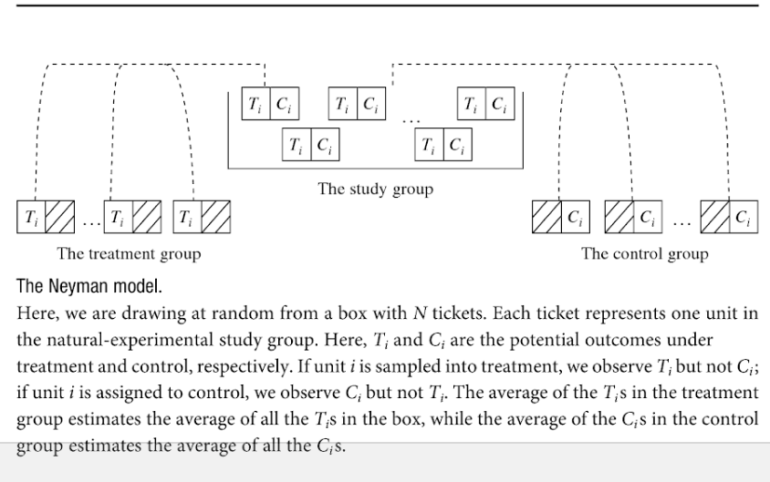

## If we randomly sample

**estimand**: $ACE = \bar{\tau} = \frac{1}{N}\sum\limits_{i=1}^N [Y_i(1) - Y_i(0)]$

We use the **estimator** ($\widehat{ACE}$ or $\widehat{\bar{\tau}}$):

$$\normalsize\underbrace{\frac{1}{m}\sum\limits_{i=1}^m}_{\text{Avg.
over T}} \overbrace{[Y_i(1) | Z_i = 1]}^{\text{Y(treated) for T}} -
\underbrace{\frac{1}{N-m}\sum\limits_{i=m + 1}^N}_{\text{Avg. over C}}
\overbrace{[Y_i(0) | Z_i = 0]}^{\text{Y(control) for C}}$$

Where units $1 \to m$ (group $T$) are assigned to treatment $Z_i = 1$ and units $(N - m) \to N$ (group $C$) assigned to control $Z_i = 0$.

## Causal Inference Using Statistics

This **estimator** ($\widehat{ACE}$) uses the

- mean value of $Y_i(1)$ for the **treatment** group (observable) to stand in for mean $\color{red}{Y_i(1)}$ for **all** units (unobservable)
- mean value of $Y_i(0)$ for the **control** group (observable) to stand in for mean $\color{red}{Y_i(0)}$ for **all** units (unobservable)

## Causal Inference Using Statistics

#### **Because we randomly assign** $Z$

1. Expected value of mean for **sample** in treatment $E[Y_i(1) | Z_i = 1]$ equals population mean $E[Y_i(1)]$
2. Expected value of mean for **sample** in control $E[Y_i(0) | Z_i = 0]$ equals population mean $E[Y_i(0)]$
3. Because **sample** means are random variables, $\widehat{ACE}$ in a sample may differ from the true $ACE$ (**estimand**).
4. Across **all possible assignments**: $E[ACE] = E[\widehat{ACE}]$, thus $\widehat{ACE}$ is unbiased.

## Algebraically:

$$ACE =\frac{1}{N}\sum\limits_{i=1}^N
[Y_i(1) - Y_i(0)]$$

$$ACE =E[Y_i(1) - Y_i(0)]$$

$$ACE = E[Y_i(1)] - E[Y_i(0)]$$

And if $Z_i$ is randomly assigned:

$$ACE = E[Y_i(1)|Z_i = 1] - E[Y_i(0)|Z_i =
0]$$
$$ACE =
E(\widehat{ACE})$$

## Key Assumptions

For us to get an **unbiased** estimator of the average causal effect, we use a statistical model that **assumes**:

1. **Random assignment**: units are sample at random (or as if at random) from the study group and assigned to treatment or control ($Z$ is independent of $Y_i(1)$ and $Y_i(0)$)
2. **Non-interference/SUTVA**: each unit’s outcome depends only on its treatment assignment (not on assignment of others)
3. **Exclusion restriction**: treatment assignment only affects outcomes through receipt of treatment

## Key Assumptions

Limitations:

- Only reveals **average** effect
- Trade-offs in terms of relevance:
  - does experimental sample reflect population of interest?
  - might there be “general equilibrium effects”?

## Design vs Model

A randomized experiment as a comparison could be used to make estimators of *different* **estimands**

- quantile treatment effects, e.g.

These would require a different set of assumptions, different estimator.

More complex experiments (e.g. testing “spillover effects”) imply different estimands, different estimators.

We focus on **canonical estimators** for each design.

# Random Variables Review

return

## Random Variables and Expectations

**random variable**: a *chance* procedure for generating a number

**observed value** (**realization**): value of a particular draw of a random variable.

## Random Variable: Example

### Six-sided fair die

- Equal probability of landing on $1,2,3,4,5,6$
- Imagine the **random variable** as a box containing all possible values of a die roll on tickets
- A roll of the die would be a **realization**

## Random Variables: Operations

#### (1) Arithmetic operations on random variables are new random variables

- E.g. $Y * X = Z$; where $Y$ is $-1,1$ based on a coin flip and $X$ is $1,2,3,4,5,6$ based on die roll.

## Random Variables: Expectations

#### (2) **Expected value** of a random variable is a number.

- If $X$ is a random draw from a box of numbered tickets, then $E(X)$ is the mean of the tickets in the box
  - $E(X)$ has **minimum distance** to all possible values of $X$
- Any **realization** of the random variable may be above or below the **expected value**

## Independence and Dependence

$X$ and $Y$ are random variables.

- If you know the value of $X$ **and** the chances of $Y$ taking on a specific value depends on that value of $X$, $X$ and $Y$ are **dependent**
- If you know the value of $X$ **and** the chances of $Y$ taking on a specific value do not depend on that value of $X$, $X$ and $Y$ are **independent**

## Independence and Dependence

| **X** | **Y** |
| --- | --- |
| 1 | 1 |
| 1 | 2 |
| 1 | 3 |
| 3 | 1 |
| 3 | 2 |
| 3 | 3 |

## Independence and Dependence

| **X** | **Y** |
| --- | --- |
| 1 | 1 |
| 1 | 2 |
| 1 | 3 |
| 3 | 2 |
| 3 | 2 |
| 3 | 3 |

## Random Variables Summary:

- We often have **data variables**: lists of numbers
- **random variables** are chance processes for generating numbers
  - permit us to use observed **realizations** to draw inferences about the random variable
- to treat **data variables** as **random variables** need to *assume* a **model** for random data generating process

## Statistics and Parameters

- Expected value and other attributes of a random variable are **parameters**/**estimands**
  - in our examples (e.g. fair die), we have known it
  - usually, we **want** to estimate it
  - (often greek letters)
- **statistics** (e.g., sample mean) are data we observe; if model assumptions hold, let us draw inferences about **parameters**.
  - (sometimes regular letters, or as **estimators** $\widehat{wearing \ hats}$)

## Statistics and Parameters

#### If we roll a die $n$ times and add up spots ($S_i$) on each roll $i$:

$$\sum\limits_{i=1}^{n}S_i$$

#### Each $S_i$ is a random variable, as is the sum

## Statistics and Parameters

It turns out that:

$$E\left(\sum\limits_{i=1}^{n}S_i\right) =
\sum\limits_{i=1}^{n}E\left(S_i\right) = n \cdot 3.5$$

$$\frac{1}{n}\sum\limits_{i=1}^{n}E\left(S_i\right)
= n \cdot 3.5 \cdot \frac{1}{n}$$

If we roll die $n$ times and take the mean of spots, it is a random variable. The mean of the $n$ draws is, in expectation, the mean of the random variable $S$. AND as $n$ gets large, sample mean will converge on the mean of $S$.

## Key Takeaway:

We can use repeated observations to estimate parameters of random variable (e.g. expected value).

We did this assuming independent and identically distributed random draws.

Good for rolling dice…

### but reality is complicated.